# White Wines Analysis Training

## WHITE WINES DATA ANALYSIS TRAINING

Celia Parejo Aranda (May-2019)

**Dataset taken from**: P. Cortez, A. Cerdeira, F. Almeida, T. Matos and J. Reis. Modeling wine preferences by data mining from physicochemical properties. In Decision Support Systems, Elsevier, 47(4):547-553, 2009.

*Information from the authors*: *red and white wines datasets can be viewed as classification or regression tasks. The classes are ordered and not balanced (e.g. there are many more normal wines than excellent or poor ones). Outlier detection algorithms could be used to detect the few excellent or poor wines. Also, we are not sure if all input variables are relevant. So it could be interesting to test feature selection methods.*

**Variables**:

- fixed acidity
- volatile acidity
- citric acid
- residual sugar
- chlorides
- free sulfur dioxide
- total sulfur dioxide
- density
- pH
- sulphates
- alcohol
- **Quality** (score between 0 and 10) (based on sensory data)

Let's start by importing the data:

```python
import numpy as np
import pandas as pd
import seaborn as sns
sns.set_style('darkgrid')
import matplotlib.pyplot as plt
%matplotlib inline
```

```python
wines = pd.read_csv('winequality-white.csv', sep = ';')
```

```python
wines.info()
```

```
<class 'pandas.core.frame.DataFrame'>
RangeIndex: 4898 entries, 0 to 4897
Data columns (total 12 columns):
fixed acidity           4898 non-null float64
volatile acidity        4898 non-null float64
citric acid             4898 non-null float64
residual sugar          4898 non-null float64
chlorides               4898 non-null float64
free sulfur dioxide     4898 non-null float64
total sulfur dioxide    4898 non-null float64
density                 4898 non-null float64
pH                      4898 non-null float64
sulphates               4898 non-null float64
alcohol                 4898 non-null float64
quality                 4898 non-null int64
dtypes: float64(11), int64(1)
memory usage: 459.3 KB
```

```python
wines.describe()
```

|  | fixed acidity | volatile acidity | citric acid | residual sugar | chlorides | free sulfur dioxide | total sulfur dioxide | density | pH | sulphates | alcohol | quality |
| --- | --- | --- | --- | --- | --- | --- | --- | --- | --- | --- | --- | --- |
| count | 4898.000000 | 4898.000000 | 4898.000000 | 4898.000000 | 4898.000000 | 4898.000000 | 4898.000000 | 4898.000000 | 4898.000000 | 4898.000000 | 4898.000000 | 4898.000000 |
| mean | 6.854788 | 0.278241 | 0.334192 | 6.391415 | 0.045772 | 35.308085 | 138.360657 | 0.994027 | 3.188267 | 0.489847 | 10.514267 | 5.877909 |
| std | 0.843868 | 0.100795 | 0.121020 | 5.072058 | 0.021848 | 17.007137 | 42.498065 | 0.002991 | 0.151001 | 0.114126 | 1.230621 | 0.885639 |
| min | 3.800000 | 0.080000 | 0.000000 | 0.600000 | 0.009000 | 2.000000 | 9.000000 | 0.987110 | 2.720000 | 0.220000 | 8.000000 | 3.000000 |
| 25% | 6.300000 | 0.210000 | 0.270000 | 1.700000 | 0.036000 | 23.000000 | 108.000000 | 0.991723 | 3.090000 | 0.410000 | 9.500000 | 5.000000 |
| 50% | 6.800000 | 0.260000 | 0.320000 | 5.200000 | 0.043000 | 34.000000 | 134.000000 | 0.993740 | 3.180000 | 0.470000 | 10.400000 | 6.000000 |
| 75% | 7.300000 | 0.320000 | 0.390000 | 9.900000 | 0.050000 | 46.000000 | 167.000000 | 0.996100 | 3.280000 | 0.550000 | 11.400000 | 6.000000 |
| max | 14.200000 | 1.100000 | 1.660000 | 65.800000 | 0.346000 | 289.000000 | 440.000000 | 1.038980 | 3.820000 | 1.080000 | 14.200000 | 9.000000 |

```python
wines.quality.describe()
```

```
count    4898.000000
mean        5.877909
std         0.885639
min         3.000000
25%         5.000000
50%         6.000000
75%         6.000000
max         9.000000
Name: quality, dtype: float64
```

We can see that the minimun punctuation that these wines have received is a 3, while the best one is a 9, and most of them are around the pass mark, with a standard deviation of almost one point.

Let's check our dataframe:

```python
wines.head()
```

|  | fixed acidity | volatile acidity | citric acid | residual sugar | chlorides | free sulfur dioxide | total sulfur dioxide | density | pH | sulphates | alcohol | quality |
| --- | --- | --- | --- | --- | --- | --- | --- | --- | --- | --- | --- | --- |
| 0 | 7.0 | 0.27 | 0.36 | 20.7 | 0.045 | 45.0 | 170.0 | 1.0010 | 3.00 | 0.45 | 8.8 | 6 |
| 1 | 6.3 | 0.30 | 0.34 | 1.6 | 0.049 | 14.0 | 132.0 | 0.9940 | 3.30 | 0.49 | 9.5 | 6 |
| 2 | 8.1 | 0.28 | 0.40 | 6.9 | 0.050 | 30.0 | 97.0 | 0.9951 | 3.26 | 0.44 | 10.1 | 6 |
| 3 | 7.2 | 0.23 | 0.32 | 8.5 | 0.058 | 47.0 | 186.0 | 0.9956 | 3.19 | 0.40 | 9.9 | 6 |
| 4 | 7.2 | 0.23 | 0.32 | 8.5 | 0.058 | 47.0 | 186.0 | 0.9956 | 3.19 | 0.40 | 9.9 | 6 |

We have already seen in the info() table that there are not any null values, but just as a way of checking:

```python
wines.isnull().sum().sort_values(ascending = False)
```

```
quality                 0
alcohol                 0
sulphates               0
pH                      0
density                 0
total sulfur dioxide    0
free sulfur dioxide     0
chlorides               0
residual sugar          0
citric acid             0
volatile acidity        0
fixed acidity           0
dtype: int64
```

So datatypes are OK, there are no missing values... The data is pretty clean.

Let's explore it.

## Exploratory analysis and feature engineering

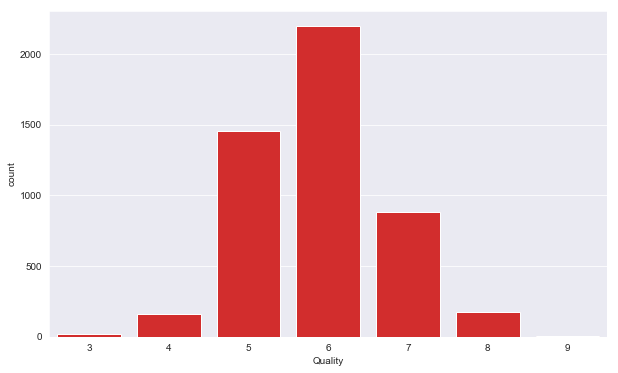

```python
plt.figure(figsize=(10,6))
sns.countplot(wines['quality'], color = 'red', saturation=0.65)
plt.xlabel('Quality')
```

As the authors mentioned in the dataset description, there are a lot more 'medium quality' wines than bad or good ones. We will have to take this into account while comparing samples, as the **data is not equally distributed** among quality marks at all.

Let's create a heatmap to get a general overview of the possible correlations using our initial numerical data:

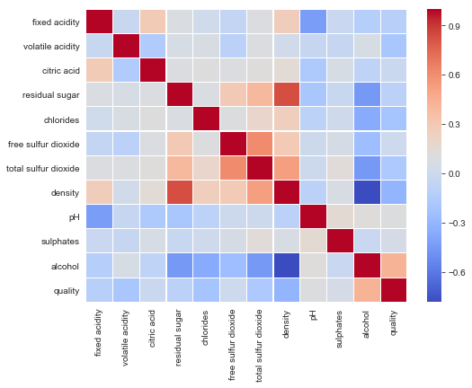

```python
plt.figure(figsize = (8,6))
sns.heatmap(wines.corr(), linewidths = .1, cmap = 'coolwarm')
```

Only alcohol seems to be correlated with quality. Let's deepen into every variable.

First: **alcohol content**:

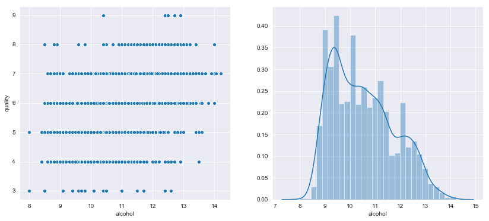

```python
fig, axs = plt.subplots(ncols=2, figsize=(14,6))

sns.scatterplot(x = 'alcohol', y = 'quality', data = wines, ax=axs[0])
sns.distplot(wines['alcohol'], ax=axs[1])
```

As we have already seen, there seems to exist some sort of relationship between alcohol content and quality. To simplify this graphs, we can create a new feature in which we divide wines into different categories according to their alcohol level:

```python
bins = np.linspace(min(wines['alcohol']), max(wines['alcohol']), 4)
group_names = ['Low', 'Medium', 'High']
wines['alcohol_binned'] = pd.cut(wines['alcohol'], bins, labels = group_names, include_lowest = True)
```

```python
wines.head()
```

|  | fixed acidity | volatile acidity | citric acid | residual sugar | chlorides | free sulfur dioxide | total sulfur dioxide | density | pH | sulphates | alcohol | quality | alcohol_binned |
| --- | --- | --- | --- | --- | --- | --- | --- | --- | --- | --- | --- | --- | --- |
| 0 | 7.0 | 0.27 | 0.36 | 20.7 | 0.045 | 45.0 | 170.0 | 1.0010 | 3.00 | 0.45 | 8.8 | 6 | Low |
| 1 | 6.3 | 0.30 | 0.34 | 1.6 | 0.049 | 14.0 | 132.0 | 0.9940 | 3.30 | 0.49 | 9.5 | 6 | Low |
| 2 | 8.1 | 0.28 | 0.40 | 6.9 | 0.050 | 30.0 | 97.0 | 0.9951 | 3.26 | 0.44 | 10.1 | 6 | Medium |
| 3 | 7.2 | 0.23 | 0.32 | 8.5 | 0.058 | 47.0 | 186.0 | 0.9956 | 3.19 | 0.40 | 9.9 | 6 | Low |
| 4 | 7.2 | 0.23 | 0.32 | 8.5 | 0.058 | 47.0 | 186.0 | 0.9956 | 3.19 | 0.40 | 9.9 | 6 | Low |

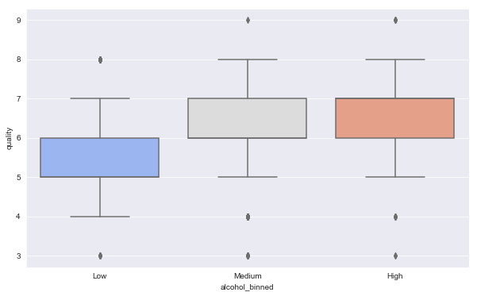

```python
plt.figure(figsize=(10,6))
sns.boxplot(x = 'alcohol_binned', y = 'quality', data = wines, palette = "coolwarm")
```

This graph clearly shows a relationship between quality and the 'alcohol' variable. It can be interesting to perform an ANOVA to check if the mean of alcohol content of the 'Medium' and 'High' quality wines are indeed higher than the low quality ones':

```python
from scipy import stats
f_val, p_val = stats.f_oneway(wines[wines['alcohol_binned'] == 'Low']['quality'],
                              wines[wines['alcohol_binned'] == 'Medium']['quality'],
                              wines[wines['alcohol_binned'] == 'High']['quality'])

print( "ANOVA results: F=", f_val, ", P =", p_val)
```

```
ANOVA results: F= 501.21367251791844 , P = 9.39749934976259e-199
```

Yes. We can state, with a 95% confidence level, that wines with low alcohol content get statistically significant lower marks than those with 'Medium' or 'High' levels of alcohol.

Let's move on. **Density** is another fundamental feature of good wines, due to the presence of glycerin, among other components. Let's see if we can find a correlation between density and quality:

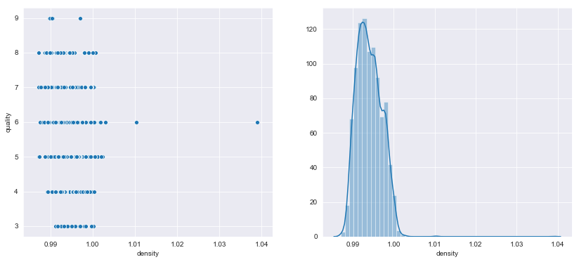

```python
fig, axs = plt.subplots(ncols=2, figsize=(14,6))

sns.scatterplot(x = 'density', y = 'quality', data = wines, ax=axs[0])
sns.distplot(wines['density'], ax=axs[1])
```

```python
wines['density'].describe()
```

```
count    4898.000000
mean        0.994027
std         0.002991
min         0.987110
25%         0.991723
50%         0.993740
75%         0.996100
max         1.038980
Name: density, dtype: float64
```

It is seems like density would not be a good feature in order to predict quality, as it is almost the same if every wine registered in this dataset.

Let's now dive into sulfur content.

But before that, we should know a bit about the **role of sulfur in wines:**

- Sulfur dioxide exists as both free sulfur dioxide and bound sulfur dioxide in wine. Winemakers use the term total sulfur dioxide when referring to the sum of both the free and bound sulfur dioxide in wine. When sulfur dioxide (sulfites) is added to young wines, about half of the added sulfur dioxide quickly combines with other wine materials, and part of the sulfur dioxide added to wine remains in the free form (free sulfur dioxide). But, when sulfur dioxide is added to mature wines that contain relatively large amounts of sulfur dioxide, very little of the added sulfur dioxide becomes bound.
- Free sulfur dioxide exists as molecular SO2, bisulfite and sulfite, and wine pH determines how free sulfur dioxide is distributed between these three forms.
- This free sulfur dioxide, an in particular, molecular SO2, protects wine against microbes and oxidation. The unpleasant burnt match odor (noticeable sulfur smell) sometimes detected in wine depends primarily on the amount of SO2 present, rather than on the amount of free sulfur dioxide, and this depends on pH.
- Large amounts of total sulfur dioxide in a wine may indicate excessive microbial activity, excessive wine oxidation, or poor storage conditions.
- Most commercial wineries measure the free SO2 content of their wines every few weeks and additional sulfur dioxide is added as needed to maintain the molecular SO2 level at about 0.8 milligrams per liter (between 0.5 and 0.8).

Source: http://www.gencowinemakers.com/docs/Sulfur%20Dioxide.pdf

Now that we know a little bit more about our friend sulfur, let's see what it can tell us.

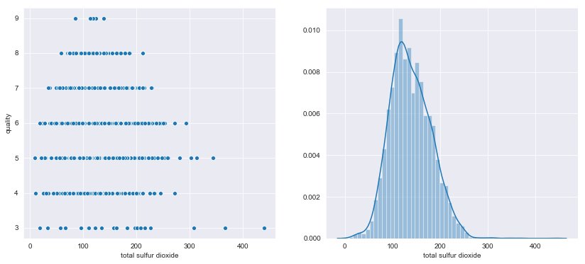

```python
fig, axs = plt.subplots(ncols=2, figsize=(14,6))

sns.scatterplot(x = 'total sulfur dioxide', y = 'quality', data = wines, ax=axs[0])
sns.distplot(wines['total sulfur dioxide'], ax=axs[1])
```

Again, let's divide wines samples according to sulfur content to see if it can be of any help understanding the data:

```python
bins = np.linspace(min(wines['total sulfur dioxide']), max(wines['total sulfur dioxide']), 6)
group_names = ['Low', 'Medium-Low', 'Medium', 'Medium-High', 'High']
wines['Total_sulf_binned'] = pd.cut(wines['total sulfur dioxide'], bins, labels = group_names, include_lowest = True)
```

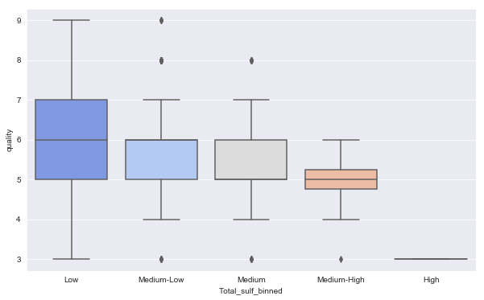

```python
plt.figure(figsize=(10,6))
sns.boxplot(x = 'Total_sulf_binned', y = 'quality', data = wines, palette = "coolwarm",
           order = ['Low', 'Medium-Low', 'Medium', 'Medium-High', 'High'])
```

It seems like the wines with the lowest quantity of total sulfur dioxide are the ones which get higher marks, and apparently this total sulfur dioxide is negatively correlated with quality. But it could also be a matter of number of samples, so let's check the distribution of our new feature 'Total_sulf_binned':

```
[Text(0.5, 0, 'Total Sulfur Dioxide Level')]
```

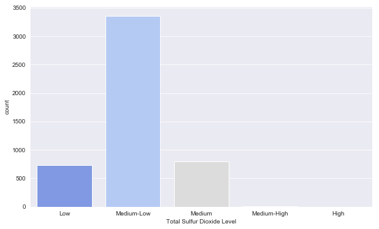

```python
plt.figure(figsize=(10,6))
ax = sns.countplot('Total_sulf_binned', data = wines, palette = "coolwarm",
              order = ['Low', 'Medium-Low', 'Medium', 'Medium-High', 'High'])
ax.set(xlabel = 'Total Sulfur Dioxide Level')
```

```python
wines.Total_sulf_binned.value_counts()
```

```
Medium-Low     3354
Medium          800
Low             734
Medium-High       8
High              2
Name: Total_sulf_binned, dtype: int64
```

Anyway, let's see what happens with, specifically, **free sulfur dioxide** by proceedind in the same way:

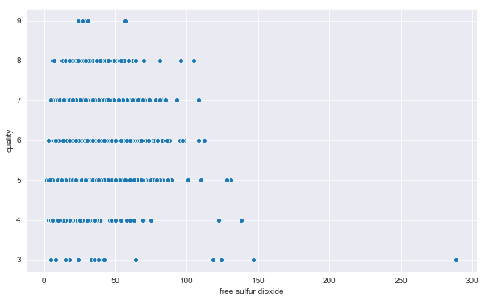

```python
plt.figure(figsize=(10,6))
sns.scatterplot(x = 'free sulfur dioxide', y = 'quality', data = wines)
```

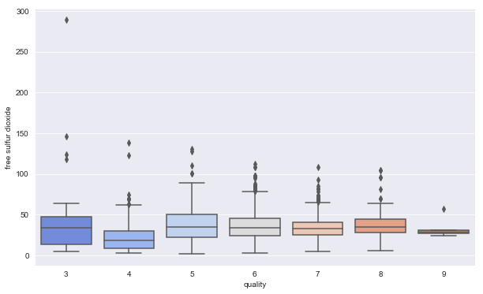

```python
plt.figure(figsize=(10,6))
sns.boxplot(x = 'quality', y = 'free sulfur dioxide', data = wines, palette = "coolwarm")
```

It is difficult to tell any difference here.

```python
bins = np.linspace(min(wines['free sulfur dioxide']), max(wines['free sulfur dioxide']), 6)
group_names = ['Low', 'Medium-Low', 'Medium', 'Medium-High', 'High']
wines['Free_sulf_binned'] = pd.cut(wines['free sulfur dioxide'], bins,
                                   labels = group_names, include_lowest = True)
```

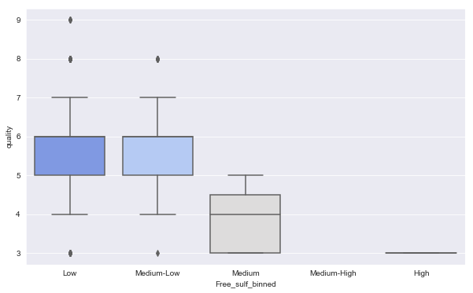

```python
plt.figure(figsize=(10,6))
sns.boxplot(y = 'quality', x = 'Free_sulf_binned', data = wines, palette = "coolwarm")
```

```python
wines.Free_sulf_binned.value_counts()
```

```
Low            4512
Medium-Low      378
Medium            7
High              1
Medium-High       0
Name: Free_sulf_binned, dtype: int64
```

Well, not much useful information apart from the fact that most wines tend to have a low or medium-low level of sulfur dioxide. This is in agreement with the information previously exposed, as large quantities of total sulfur dioxide are definitely not wanted *('Large amounts of total sulfur dioxide in a wine may indicate excessive microbial activity, excessive wine oxidation, or poor storage conditions').*

What about the **pH value**?

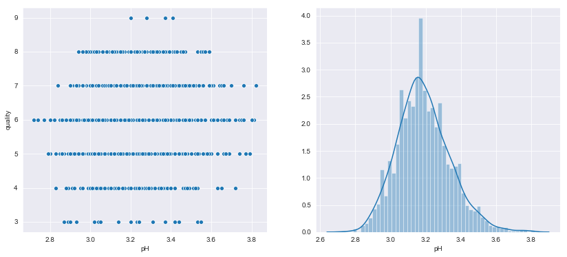

```python
fig, axs = plt.subplots(ncols=2, figsize=(14,6))

sns.scatterplot(x = 'pH', y = 'quality', data = wines, ax=axs[0])
sns.distplot(wines['pH'], ax=axs[1])
```

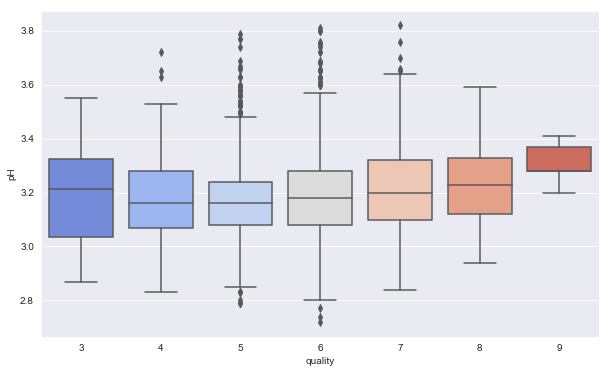

```python
plt.figure(figsize=(10,6))
sns.boxplot(x = 'quality', y = 'pH', data = wines, palette = "coolwarm")
```

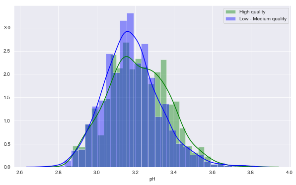

```python
plt.figure(figsize=(10,6))

sns.distplot(wines[(wines['quality'] == 7) | (wines['quality'] == 8) | (wines['quality'] == 9)]['pH'],
             bins = 30, color = 'green', label='High quality')
sns.distplot(wines[-(wines['quality'] == 7) | (wines['quality'] == 8) | (wines['quality'] == 9)]['pH'],
             bins = 30, color = 'blue', label='Low - Medium quality')
plt.legend()
plt.xlabel('pH')
```

```python
print('pH value of wines with best marks (7, 8 or 9) are within',
      wines[(wines['quality'] == 7) | (wines['quality'] == 8) |
            (wines['quality'] == 9)]['pH'].min(), 'and',
      wines[(wines['quality'] == 7) | (wines['quality'] == 8) |
                  (wines['quality'] == 9)]['pH'].max())

print('With a mean value of', round(wines[(wines['quality'] == 7) |
                                    (wines['quality'] == 8) |
                                          (wines['quality'] == 9)]['pH'].mean(), 2))
print('\n')

print('pH value of wines with medium or low marks (3-6) are within',
      wines[-(wines['quality'] == 7) | (wines['quality'] == 8) |
            (wines['quality'] == 9)]['pH'].min(),
      'and',wines[(wines['quality'] == 7) |
                  (wines['quality'] == 8) |
                  (wines['quality'] == 9)]['pH'].max())

print('With a mean value of', round(wines[(wines['quality'] == 3) |
                                    (wines['quality'] == 4) |
                                          (wines['quality'] == 5) |
                                          (wines['quality'] == 6)]['pH'].mean(), 2))
```

```
pH value of wines with best marks (7, 8 or 9) are within 2.84 and 3.82
With a mean value of 3.22


pH value of wines with medium or low marks (3-6) are within 2.72 and 3.82
With a mean value of 3.18
```

According to our results, we cannot define a specific relationship between pH and quality. Besides, as we already know, the great majority of the samples have a mark of 6, which makes it difficult to compare groups.

Let's continue with **acidity**.

**Quick note about citric acid's origin in wines**: according to the internet, *'While citric acid is very common in citrus fruits, (...) it is found only in very minute quantities in wine grapes (...). The citric acid most commonly found in wine is **commercially produced acid supplements** derived from fermenting sucrose solutions (...). Often to increase acidity of wine, winemakers will add tartaric acid instead'*.

Knowing this, logic makes me think that the higher amount of citric acid, the lower the quality must be, as citric acid is nothing but a way to 'correct' acidity, which means that something went wrong during the fermentation period for whatever reason.

Let's check that:

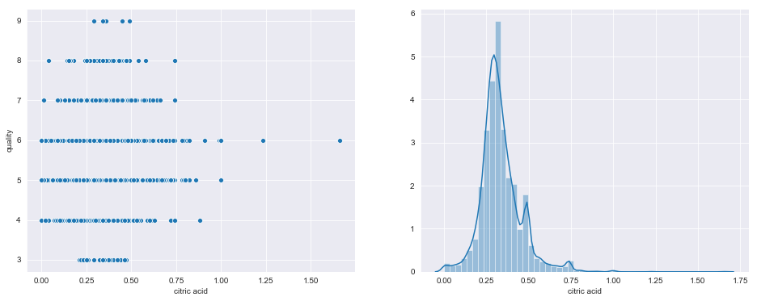

```python
fig, axs = plt.subplots(ncols=2, figsize=(16,6))

sns.scatterplot(x = 'citric acid', y = 'quality', data = wines, ax=axs[0])
sns.distplot(wines['citric acid'], ax=axs[1])
```

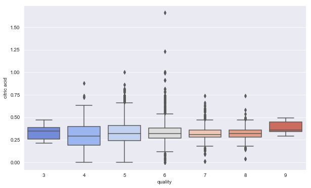

```python
plt.figure(figsize=(10,6))
sns.boxplot(x = 'quality', y = 'citric acid', data = wines, palette = "coolwarm")
```

It is seems that my hypothesis was wrong. Again, no sign of direct correlation.

As far as **total acidity** is concerned, it is the sum of the **fixed and volatile acids**, and also known as titratable acidity. Let's see if it correlates with quality:

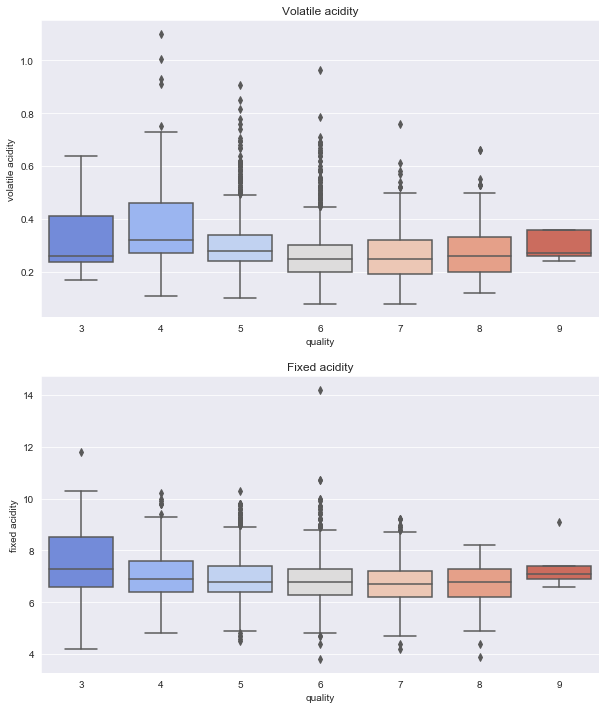

```python
fig = plt.figure(figsize = (10,12))

ax1 = fig.add_subplot(211)
ax2 = fig.add_subplot(212)

sns.boxplot(x = 'quality', y = 'volatile acidity', data = wines,
            palette = "coolwarm", ax=ax1).set_title('Volatile acidity')
sns.boxplot(x = 'quality', y = 'fixed acidity', data = wines,
            palette = "coolwarm", ax=ax2).set_title('Fixed acidity')
```

There doesn't seem to be a general trend. The presence of many outliers also masks any possible little correlation.

Next step will be **residual sugar**, which is correlated with wine's sweetness.

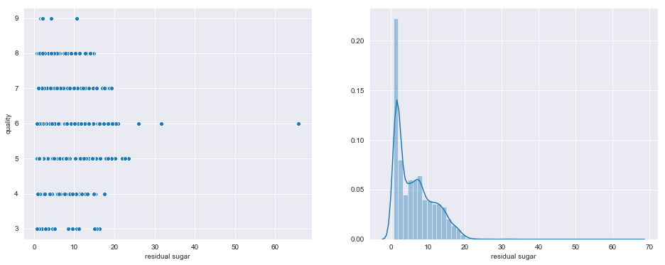

```python
fig, axs = plt.subplots(ncols=2, figsize=(16,6))

sns.scatterplot(x = 'residual sugar', y = 'quality', data = wines, ax=axs[0])
sns.distplot(wines['residual sugar'], ax=axs[1])
```

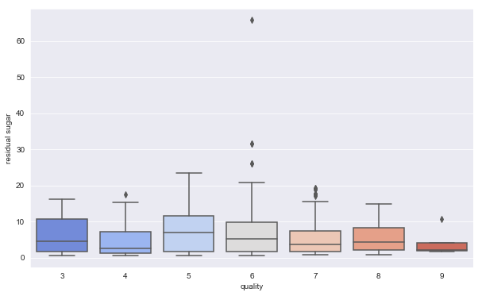

```python
plt.figure(figsize=(10,6))
sns.boxplot(x = 'quality', y = 'residual sugar', data = wines, palette = "coolwarm")
```

Finally, let's go with chlorides and sulfates.